# Datathon Submission Template

[Retina AI](https://retina.ai)

24 September, 2020

## Retina AI R Datathon - Submission Template

*Team Name*: Bruin AI  
*Team Members*: Louis Zhao, Sophie Yun, Ananya Sini Achan  
*Team Members Email*: Lozhao@g.ucla.edu, yilingsophie@ucla.edu, ananyabruin22@g.ucla.edu  
*Designated Slides*: 27, 28

*Directions*: Write your text and codes for Task 1, 2 and 3 in the provided space below.

Task 1 insights to the visualization can be written as plain text in the field provided below. You can also add new bullet points to each slide’s insights section.

For Task 2 and 3, provide your codes in the code chunks below. If your team needs additional code chunks to run your code, you can add new code chunks.

## Task 1 (Required)

*Slide Number*: 27

*Key Insights min 2 / max 4*: - First year retention rates has a downward trend. For each year after 2016, there is on average a 1.55 percent decrease in retention rates for the first following year without including 2020 data and 3.61 percent decrease including. Some possible explanations could be a deterioration of retention efforts on the part of the company especially with the substantial increase in customer growth, or an increase of competition within the market leading to higher turnover rates from year to year.  
- The rate and probability of churn decreases the longer a customer stays committed towards the product. There is an average year over year 41.3 percent decrease in the percentage of customers which churn from the previous year. If we were to include 2020’s data, that rate would be 28 percent. This shows that churn rate is not linear over time and there is some brand loyalty towards the product.  
- Business Insights: Groomers is doing well with the retention rates of existing customers who are already repeat purchasers of their product. This means that if a customer has repurchased the product the following year, they are more likely to purchase the product again the next year compared to a new customer. However, Groomers is not doing well year over year in terms of retaining a consistent percentage of new customers. As the Groomer’s revenue and customer base grows, the company should focus on retaining new customers at a more consistent rate. Some possible solutions could be analyzing and addressing potential market competition or improving the core customer experience.

*Slide Number*: 28

## Task 2 (Required)

*Slide Number*: 27

[output not shown]

*Slide Number*: 28

[output not shown]

```
## The general trend is that the greater the Lifetime Revenue (5 year) the higher the Series 1. These two factors follow a positive linear relationship. Therefore, if the company wants to improve Series 1, the company should focus on the customers with low Lifetime Revenue (5 year).
```

[output not shown]

## Task 3 (Bonus/Optional)

*Key Insights min 2 / max 4*: - Changes in average retention and actually retained customers follow similar patterns every year. This is shown by the spikes in retention numbers in November and May which is then followed by a usual decrease in June. These seasonal patterns can be capitalized by the Groomer’s team to push profit margins by increasing their marketing efforts to existing customers during May and November. The team should also try to explain why there is a sharp decrease in June: maybe Groomer’s products are seasonal or perhaps the product exists on a two month life cycle.  
- While retention rates were higher in 2016 and subsequently decreased every year since, the number of actually retained customers has been going up significantly. Therefore the two numbers tell different stories and this can be attributed to the rise in customer growth for Groomers. While this company has not been able to improve their retention rates as a proportion to their total customer base, they have been retaining more customers overall.

*How to read this chart*: - The chart on the left is retention rate by month in percentage. The y axis is the average retention rate for a month across years. The x axis marks different months of a year. Different colors indicate the different years, the darker color marks the eariler years.  
- The chart on the right is number of actual retained customers by month. The y axis is the average number of retained customers for a month across years. The x axis marks different months of a year. Different colors indicate the different years, the darker color marks the eariler years.

[output not shown]

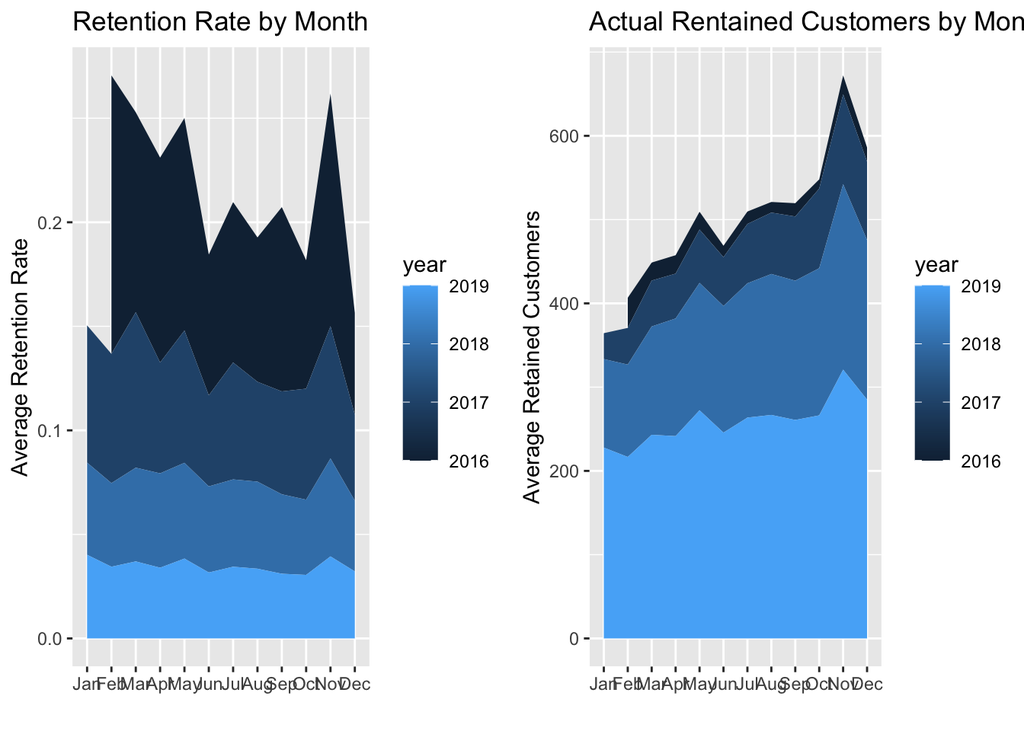